# Nuuksio LAS

Tuija Sonkkila

November 2019

This notebook has been adapted from `session3.2-lidR-LAS-class.Rmd` included in the [LiDAR course material](https://www.csc.fi/web/training/-/lidar-data-analysis-in-taito-with-pdal-and-r) by CSC. Their material in turn is based on [the wiki documentation](https://github.com/Jean-Romain/lidR/wiki) of the lidR package.

# The lidR package

lidr is an R package for Airborne LiDAR Data Manipulation and Visualization for Forestry Applications.

The lidR package provides functions to read and write `.las` and `.laz` files, plot point clouds, compute metrics using an area-based approach, compute digital canopy models, thin lidar data etc.

```r
library("lidR")
```

## Build a LAS object reading a las file

From the download service by [National Land Survey of Finland/Maanmittauslaitos (NLSF/MML)](https://tiedostopalvelu.maanmittauslaitos.fi/tp/kartta?lang) I ordered the grid labelled L4132D2 which is inside the Nuuksio National Park in Espoo.

The zipped file is around 100 MB, and the metadata tells e.g. that the scanning was done on 2.8.2015 from the flight altitude of 2033 m with a Leica ALS 60 scanner.

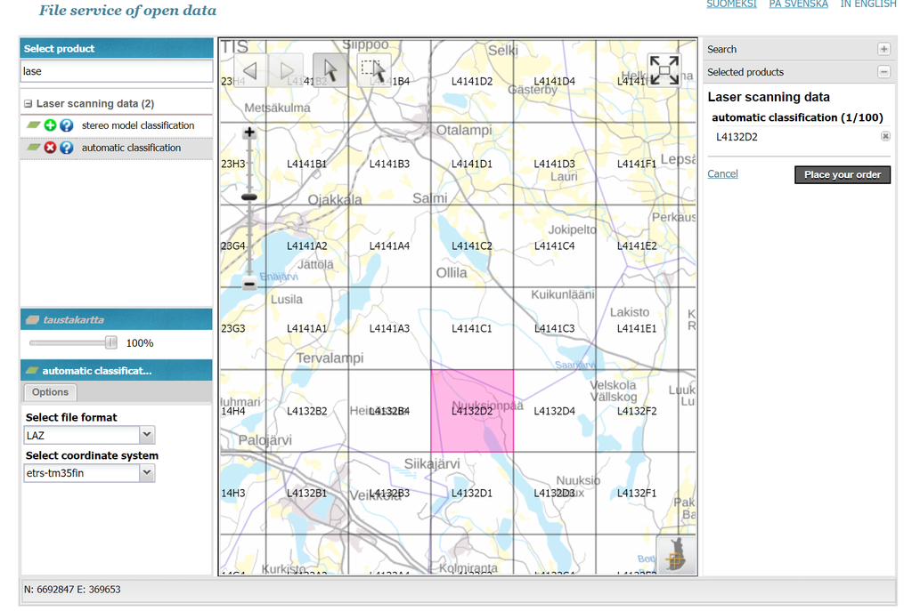

Nuuksio grid

The lidR package can read zipped LAZ files so I ignored the [advice by NLSF](https://www.maanmittauslaitos.fi/en/e-services/open-data-file-download-service) to unzip it first with the laszip tool.

```r
LASfile <- "L4132D2.laz"
las <- readLAS(LASfile)
print(las)
```

```
## class        : LAS (LASF v1.2)
## point format : 1
## memory       : 1.6 Gb
## extent       :362000, 365000, 6687000, 6690000 (xmin, xmax, ymin, ymax)
## coord. ref.  : +proj=utm +zone=35 +ellps=GRS80 +towgs84=0,0,0,0,0,0,0 +units=m +no_defs
## area         : 9 km²
## points       : 21.47 million points
## density      : 2.39 points/m²
## names        : X Y Z gpstime Intensity ReturnNumber NumberOfReturns ScanDirectionFlag EdgeOfFlightline Classification Synthetic_flag Keypoint_flag Withheld_flag ScanAngleRank UserData PointSourceID
```

The memory use of this `las` object is whopping 1.6 Gb so as advised I clipped it down to 500 x 500 m. The original covered an area of 9 km2.

```r
las_small <- lasclipRectangle(las, las@bbox[1], las@bbox[2], las@bbox[1] + 500, las@bbox[2] + 500)
print(las_small)
```

```
## class        : LAS (LASF v1.2)
## point format : 1
## memory       : 73.4 Mb
## extent       :362000, 362500, 6687000, 6687500 (xmin, xmax, ymin, ymax)
## coord. ref.  : +proj=utm +zone=35 +ellps=GRS80 +towgs84=0,0,0,0,0,0,0 +units=m +no_defs
## area         : 246692.5 m²
## points       : 961.6 thoushand points
## density      : 3.9 points/m²
## names        : X Y Z gpstime Intensity ReturnNumber NumberOfReturns ScanDirectionFlag EdgeOfFlightline Classification Synthetic_flag Keypoint_flag Withheld_flag ScanAngleRank UserData PointSourceID
```

```r
rm(las)
gc()
```

```
##            used (Mb) gc trigger   (Mb)  max used   (Mb)
## Ncells  1527711 81.6    2380511  127.2   2380511  127.2
## Vcells 12012969 91.7  271819925 2073.9 335161074 2557.1
```

## Display a LAS object

lidR provides a simple `plot` function to plot a LAS object in 3D. It is based on the `rgl` package.

```r
plot(las_small)
```

## Creating a Digital Terrain Model

lidR has several tools and algorithms to manipulate and process lidar data. You can see them in the [Man pages for lidR](https://rdrr.io/github/Jean-Romain/lidR/man/).

The `grid_terrain` function creates a DTM by interpolating ground points. You can use three algorithms for this task `nnidw`, `tin` and `riging`, in the example below I use the `tin` algorithm. The result is an R RasterLayer.

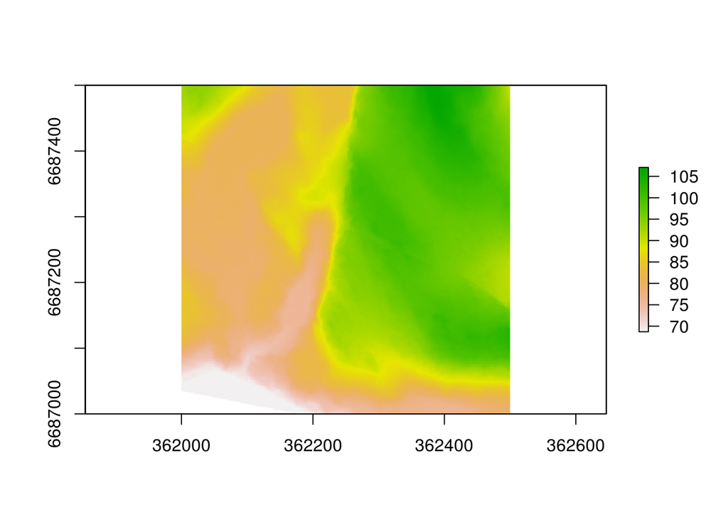

```r
dtm <- grid_terrain(las_small, algorithm = tin())
plot(dtm)
```

## Segment individual trees and compute metrics

The following is adapted from the [Segment individual trees and compute metrics](https://github.com/Jean-Romain/lidR/wiki/Segment-individual-trees-and-compute-metrics) example by Jean-Romain.

### Classify ground points

`lasground` provides several algorithms to classify ground points. Just like in the CSC notebook, I use the csf algorithm. From the [documentation](https://www.rdocumentation.org/packages/RCSF/versions/1.0.1):

> Cloth Simulation Filter (CSF) is an airborne LiDAR (Light Detection and Ranging) ground points filtering algorithm which is based on cloth simulation. It tries to simulate the interactions between the cloth nodes and the corresponding LiDAR points, the locations of the cloth nodes can be determined to generate an approximation of the ground surface.

```r
las_small <- lasground(las_small, csf())
```

```
## Original dataset already contains 127999 ground points. These points were reclassified as 'unclassified' before performing a new ground classification.
```

```r
plot(las_small, color = "Classification")
```

### Height normalize the dataset

We need to set the ground at 0. We could subtract the DTM to obtain ground points at 0 but here we won’t use a DTM but we will rather interpolate each point exactly.

It is important to notice here that neither the ground classification nor the DTM interpolation where performed using a buffer around the region of interest.

```r
las_small <- lasnormalize(las_small, tin())
```

```r
plot(las_small)
```

### Tree segmentation

There are several methods to segment the trees in lidR. Here I use watershed.

### Compute a canopy height model

In the next steps I will use an algorithm that requires an canopy height model. So, let’s compute a digital surface model with the pit-free algorithm.

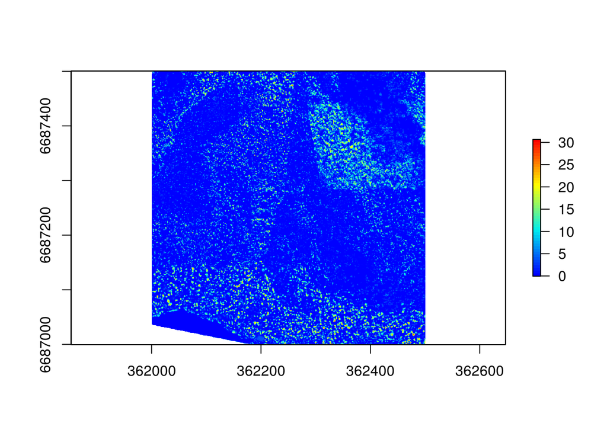

```r
algo = pitfree(thresholds = c(0,10,20,30,40,50), subcircle = 0.2)
chm  = grid_canopy(las_small, 0.5, algo)
plot(chm, col = height.colors(50))
```

### Segment the trees

The segmentation can be achieved with lastrees. Here I chose the watershed algorithm with a threshold of 4 meters. The point cloud has been updated and each point now has a number that refers to an individual tree (treeID). Points that not trees are assigned the id value NA.

```r
algo <- watershed(chm, th = 4)
las_small  <- lastrees(las_small, algo)

# remove points that are not assigned to a tree
trees <- lasfilter(las_small, !is.na(treeID))
plot(trees, color = "treeID", colorPalette = pastel.colors(100))
```

### Compute some metrics and hulls

```r
metric <- tree_metrics(las_small, .stdtreemetrics)
hulls  <- tree_hulls(las_small)
hulls@data <- dplyr::left_join(hulls@data, metric@data)
```

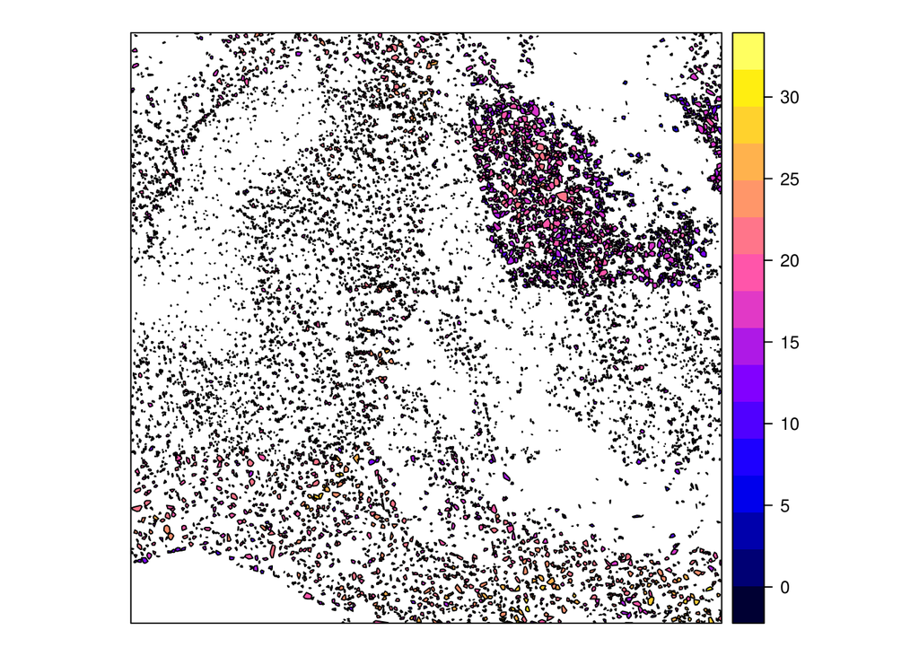

```r
spplot(hulls, "Z")
```